# MLE & MAP

LinyiGuo

2019/9/22

**Considering the parameters from Bayesian standpoint**

I am still not very clear about my goal until now, which is pretty bad. Sometimes, I think ‘Oh here it is! This is what I want!’ but after a few days(actually, often after meeting with Aaron or someone else), I realize ‘What? This is what I want? What’s the meaning of it?’ I feel my goal of research is always changed although they are all related to seasonal adjustment. I just do not know what they want actually.

At first, I thought they just want to smooth the curve of series after seasonal adjustment, when I got there, they told me something else.

Now, appatently I can achieve any kind of smoothness of any kind of curve, but I achieved these by forcing parameters manually. In **frequentist**, we prefer to let the data to ‘speak’, which would be more convictive. From this point of view, it seems to be meaningless to have different smoothness curves, although the truth may be not one and only. Also, from **Bayesian**, we hope our data help us to adjust our prior and ‘speak’ as well.

From the results in frequentist and Bayesian, we could have a MLE or MAP value of parameters, and with the help of Kalman filter, we could plot the corresponding curves. In frequentist, the process can be achieved only once, but in Bayesian, we can apply the same procedure in different prior families and choose one better prior in one family.

Having saied so much, we need to show something real.

For the expression in SSM,

- $y_t = \mu_t+\gamma_t + \epsilon_t$ , where $\epsilon_t \sim N(0,\sigma_y^2)$
- $\mu_{t+1} = \mu_t + \phi_t$ , where $\phi_t \sim N(0,\sigma_\mu^2)$
- $\gamma_t= \sum_{j=1}^{s/2} \gamma_{jt}$
- $\gamma_{j,t+1} = \gamma_{jt} cos\lambda_j + \gamma_{jt}^* sin\lambda_j + \omega_{jt}$
- $\gamma_{j,t+1}^* = - \gamma_{jt} sin\lambda_j + \gamma_{jt}^* sin\lambda_j + \omega_{jt}^*$ , where $\omega_{jt},\omega_{jt}^* \sim N(0,\sigma_\gamma^2)$

**NOTE** We may use the ‘dummy’ expression of the seasonal component later.

```r
library(seasonal)
library(forecast)
library(KFAS)
library(tseries)
```

```r
data("AirPassengers")
data_em <- unemp
mod_em_seats <- seas(data_em)
summary(mod_em_seats) # no outliers
```

```
##
## Call:
## seas(x = data_em)
##
## Coefficients:
##                   Estimate Std. Error z value Pr(>|z|)
## AR-Nonseasonal-01   0.9436     0.0344    27.4   <2e-16 ***
## MA-Nonseasonal-01   0.8254     0.0565    14.6   <2e-16 ***
## MA-Seasonal-12      0.8507     0.0336    25.3   <2e-16 ***
## ---
## Signif. codes:  0 '***' 0.001 '**' 0.01 '*' 0.05 '.' 0.1 ' ' 1
##
## SEATS adj.  ARIMA: (1 1 1)(0 1 1)  Obs.: 323  Transform: none
## AICc: 4.32e+03, BIC: 4.34e+03  QS (no seasonality in final):   0
## Box-Ljung (no autocorr.):   22   Shapiro (normality): 0.995
```

```r
data_em_pre <- series(mod_em_seats, 'b1') # preprocess but useless in this case
```

In **KFAS**, *fitSSM* is used to compute the mle of parameters, given some user-defined function. (**NOT TRIED**)

```r
em_ssm <- SSModel(data_em ~ SSMtrend(1, Q = list(1)) +
                        SSMseasonal(12,Q=1, sea.type = "dummy"), H=1)
mod_em_ssm <- KFS(em_ssm)
```

I am going to apply the following algorithm to calculate the **MLE** of variances in our model.

In our case, I define the convergence is :
$$Var(seasadj_{seats} - seasadj_{ssm}) \le 1$$

*Comment from Aaron:* ‘I think that the typical “stop” condition is when your estimates have stopped changing much from one round of the algorithm to the next.’

So, maybe I can exchange the convergence into something like:
$$\Arrowvert \theta_t - \theta_{t-1} \Arrowvert_{l_2} \le 0.01$$

```r
# define the expression of MLE
var_y_hat <- function(Trend, Season, Obs){
  sum((Obs-Trend-Season)^2)/length(Obs)
}

var_T_hat <- function(Trend){
  sum((Trend[2:length(Trend)]-Trend[1:(length(Trend)-1)])^2)/(length(Trend)-1)
}

var_S_hat <- function(Season) {
  a = 0
  for(t in 12:length(Season)){
    a = a + sum(Season[(t-11):t])^2
  }
  return(a/(length(Season)-11))
}

var_seasadj <- function(seats,ssm){
  seasadj_ssm <- data_em - rowSums(coef(ssm, states = "seasonal"))
  data <- series(seats, "s11") - seasadj_ssm
  return(var(data))
}
```

```r
# apply the algorithm
Dif <-c()
theta <- c(0.1,0.1,0.1)
Theta <- theta
for (i in 1:20){ # I define the iterations at first instead of using convergence as a stop condition

  mod <- SSModel(data_em ~ SSMtrend(1, Q=list(theta[1]))+
                   SSMseasonal(12,sea.type="dummy", Q=theta[2]), H=theta[3])
  ssm <- KFS(mod)
  Trend <- coef(ssm, states="trend")
  Season <- rowSums(coef(ssm, states="seasonal"))

  theta[1] <- var_y_hat(Trend, Season, Obs=data_em)
  theta[2] <- var_T_hat(Trend)
  theta[3] <- var_S_hat(Season)
  Theta <- rbind(Theta, theta)

  dif <- var_seasadj(mod_em_seats, ssm)
  Dif <- c(Dif, dif)

}
Dif
```

```
##  [1] 580663 560563 564467 563656 563807 563778 563784 563783 563783 563783
## [11] 563783 563783 563783 563783 563783 563783 563783 563783 563783 563783
```

```r
Theta
```

```
##           [,1]    [,2]   [,3]
## Theta      0.1     0.1    0.1
## theta 591233.9 20507.8 3263.9
## theta 556079.0 45737.0  148.0
## theta 561041.2 40073.7  430.9
## theta 559987.0 41101.4  363.8
## theta 560182.3 40906.1  375.9
## theta 560145.3 40942.9  373.6
## theta 560152.3 40936.0  374.1
## theta 560151.0 40937.3  374.0
## theta 560151.2 40937.0  374.0
## theta 560151.2 40937.1  374.0
## theta 560151.2 40937.1  374.0
## theta 560151.2 40937.1  374.0
## theta 560151.2 40937.1  374.0
## theta 560151.2 40937.1  374.0
## theta 560151.2 40937.1  374.0
## theta 560151.2 40937.1  374.0
## theta 560151.2 40937.1  374.0
## theta 560151.2 40937.1  374.0
## theta 560151.2 40937.1  374.0
## theta 560151.2 40937.1  374.0
```

```r
head(coef(mod_em_ssm))
```

```
##          level sea_dummy1 sea_dummy2 sea_dummy3 sea_dummy4 sea_dummy5
## Jan 1990  6613      785.9     -443.5     -400.6     -652.9     -344.6
## Feb 1990  6598      738.8      785.9     -443.5     -400.6     -652.9
## Mar 1990  6624      284.4      738.8      785.9     -443.5     -400.6
## Apr 1990  6707     -141.7      284.4      738.8      785.9     -443.5
## May 1990  6735     -185.6     -141.7      284.4      738.8      785.9
## Jun 1990  6778      212.8     -185.6     -141.7      284.4      738.8
##          sea_dummy6 sea_dummy7 sea_dummy8 sea_dummy9 sea_dummy10
## Jan 1990     -109.5      256.6      212.8     -185.6      -141.7
## Feb 1990     -344.6     -109.5      256.6      212.8      -185.6
## Mar 1990     -652.9     -344.6     -109.5      256.6       212.8
## Apr 1990     -400.6     -652.9     -344.6     -109.5       256.6
## May 1990     -443.5     -400.6     -652.9     -344.6      -109.5
## Jun 1990      785.9     -443.5     -400.6     -652.9      -344.6
##          sea_dummy11
## Jan 1990       284.4
## Feb 1990      -141.7
## Mar 1990      -185.6
## Apr 1990       212.8
## May 1990       256.6
## Jun 1990      -109.5
```

```r
sum((data_em - rowSums(series(mod_em_seats,c('s10','s12'))))^2)/length(data_em) # mle of sigma_y^2 is 5843
```

```
## [1] 5843
```

```r
sum((series(mod_em_seats,'s12')[2:length(series(mod_em_seats,'s12'))] -
       series(mod_em_seats,'s12')[1:(length(series(mod_em_seats,'s12'))-1)])^2)/(length(series(mod_em_seats,'s12'))-1) # mle of sigma_T^2 is 26898.92
```

```
## [1] 26899
```

```r
L <- length(series(mod_em_seats, 's10'))
a = 0
for(t in 12:L){
    a = a + sum(series(mod_em_seats,'s10')[(t-11):t])^2
  }
  return(a/(length(Season)-11))
```

```
## [1] 178.9
```

```r
sum((data_em - rowSums(coef(mod_em_ssm)))^2)/length(data_em) #591234
```

```
## [1] 591234
```

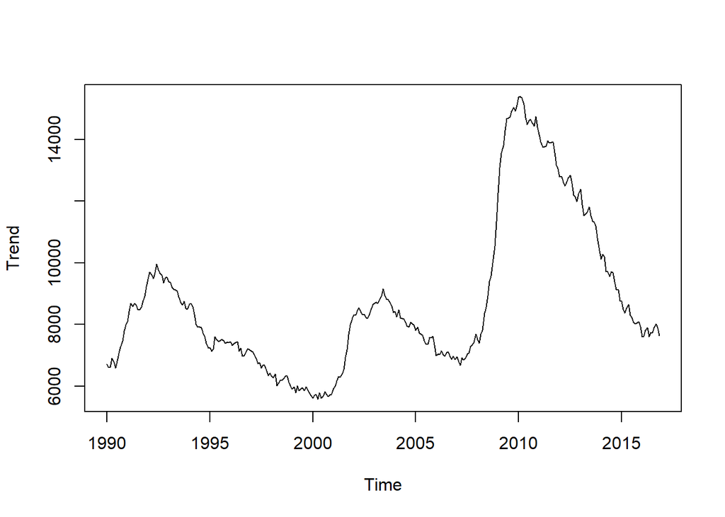

```r
plot(Trend)
```

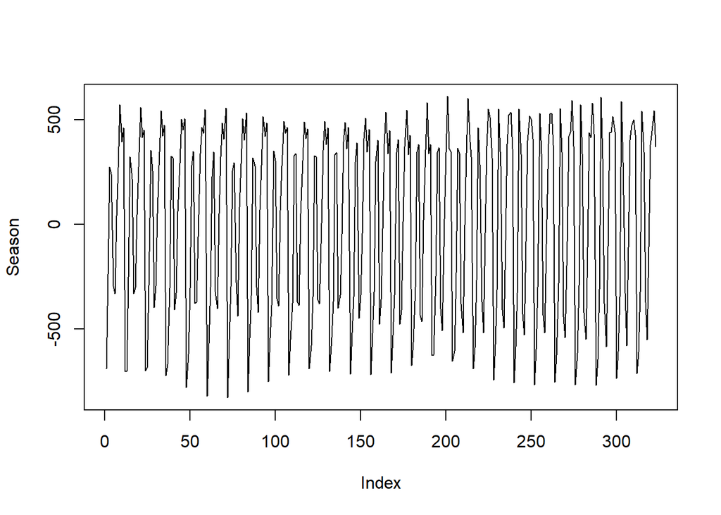

```r
plot(Season, type = 'l')
```

```r
series(mod_em_seats,'s10')
```

```
##           Jan      Feb      Mar      Apr      May      Jun      Jul
## 1990  801.483  695.923  371.850 -268.861 -288.881  325.189  304.748
## 1991  800.169  695.039  374.713 -271.213 -288.592  334.049  311.539
## 1992  797.317  686.697  371.434 -276.731 -292.536  342.357  323.621
## 1993  793.801  672.008  366.291 -280.065 -299.337  342.798  333.726
## 1994  790.116  656.005  363.196 -281.688 -305.456  340.505  344.764
## 1995  782.763  636.700  357.503 -287.637 -309.918  339.284  354.524
## 1996  777.185  624.320  355.740 -299.070 -317.198  339.076  360.421
## 1997  769.663  615.484  355.032 -313.630 -326.885  342.559  365.769
## 1998  759.077  606.698  351.000 -327.095 -335.820  347.653  371.397
## 1999  749.819  599.541  345.159 -336.583 -341.378  352.771  376.531
## 2000  744.469  594.513  341.210 -344.547 -346.229  358.062  380.715
## 2001  742.305  590.030  337.432 -352.308 -352.237  363.868  385.541
## 2002  740.471  587.310  332.986 -360.510 -353.964  375.300  398.567
## 2003  731.910  581.800  323.988 -375.219 -354.189  386.468  416.899
```

[output cut: 41 more lines]

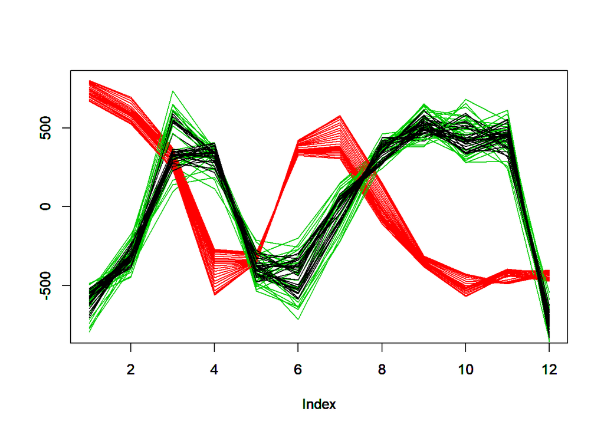

```r
for (i in 1:27) {
  plot(series(mod_em_seats,'s10')[(1+(i-1)*12): (12*i)], type = 'l',
       ylim=c(-800,800), ylab='', col=2)
  par(new=TRUE)
  plot(Season[(1+(i-1)*12): (12*i)], type='l', ylim = c(-800,800), ylab='')
  par(new=TRUE)
  plot(rowSums(coef(mod_em_ssm,states = 'seasonal'))[(1+(i-1)*12): (12*i)],
       type='l', col=3, ylim=c(-800,800),ylab='')
  par(new=TRUE)
}
for( i in 1:17){
  plot(Season[(1+(i-1)*12): (12*i)], type='l', ylim = c(-800,800), ylab='')
  par(new=TRUE)
}
```

—————————- UPDATE ————————————-

The algorithm above should be wrong, since the final seasonal component after iterations is totally different from that from TRAMO-SEATS. I will try it again.

[figure not shown]

[figure not shown]